# MI.com Call Planning Analysis

Yan Chong

## Deck Outline

- Introduction to the Problem
- Exploratory Data Analysis
  - Time Series Plot
  - Correlation
  - Explanatory Modeling using Poisson Regression
  - Outliers & Goodness-of-Fit
- Predictive Modeling
- Prescriptive Analytics
  - First Intuition
  - M/M/1 Model
- Conclusion
- Appendix for the Geeks

## Introduction to the Problem

- MI.com is a website for accommodation booking, based in UK, offering low-priced accommodations.
- It now has about 500k bookings a day.
- Customers call MI.com to query about their hotel and apartments.
- The purpose of the deck is to present the model that is best able to
  - represent the effects of the different variables
  - arrive at a predictive model to predict calls
  - think about prescriptive modeling for headcount planning

## Exploratory Data Analysis

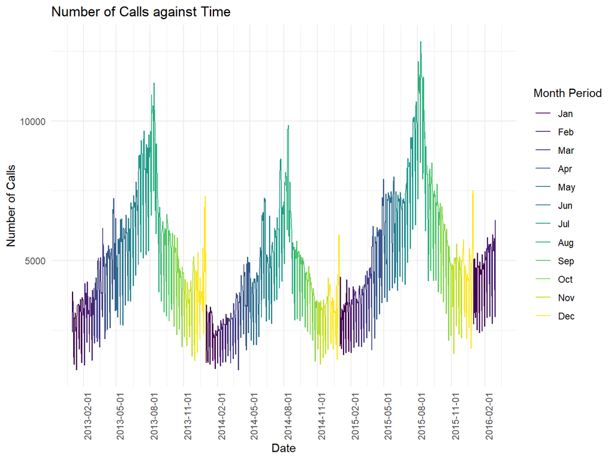

Yearly seasonal effect is present. The number of calls peaks in Aug while the trough happens in Feb period.

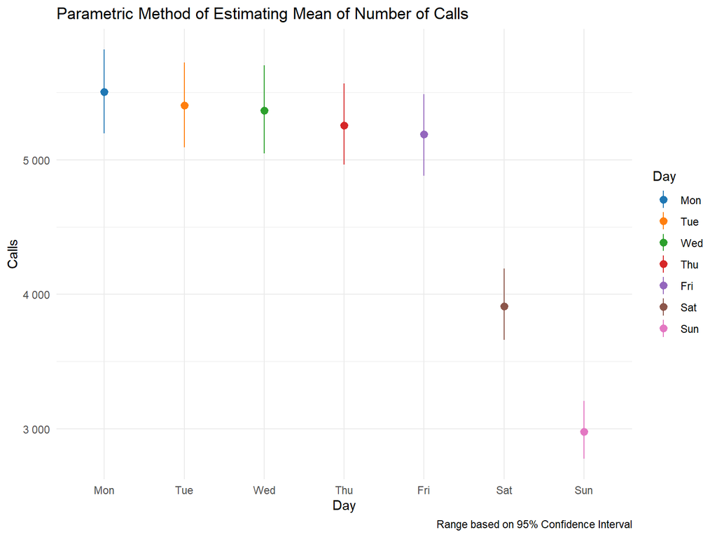

It can also be seen that weekends have substantially less calls compared to weekdays. And the number of calls across the 5 weekdays are generally consistent within the 95 % confidence interval.

## Exploratory Data Analysis

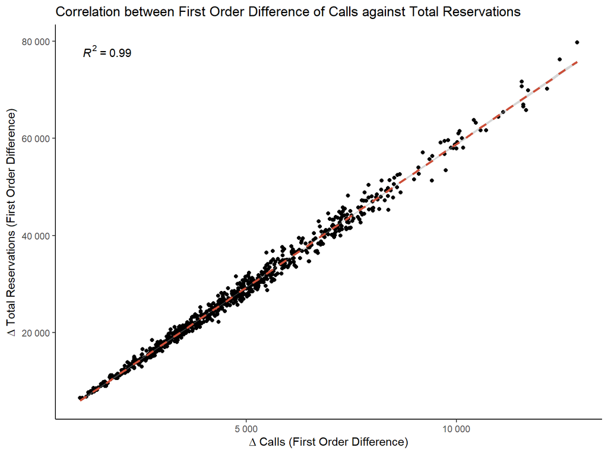

```
##
##  Pearson's product-moment correlation
##
## data:  combined_corr$PreviousCalls and combined_corr$PreviousTotalReservations
## t = 300.71, df = 787, p-value < 2.2e-16
## alternative hypothesis: true correlation is not equal to 0
## 95 percent confidence interval:
##  0.9950294 0.9962397
## sample estimates:
##       cor
## 0.9956766
```

The statistical method further affirms the strong positive linear relationship between `total_reservations` and `calls`.

## Explanatory Model using Poisson Regression

```
##
## Call:
## glm(formula = calls ~ ., family = "poisson", data = combined_data_model)
##
## Deviance Residuals:
##     Min       1Q   Median       3Q      Max
## -52.614   -4.594    0.663    5.143   20.189
##
## Coefficients:
##                                Estimate Std. Error  z value Pr(>|z|)
## (Intercept)                   7.618e+00  2.149e-03 3544.896  < 2e-16 ***
## weekdayTues                  -8.766e-03  1.845e-03   -4.752 2.02e-06 ***
## weekdayWed                   -2.456e-03  1.846e-03   -1.330   0.1835
## weekdayThurs                 -3.280e-03  1.837e-03   -1.785   0.0742 .
## weekdayFri                   -9.586e-03  1.858e-03   -5.158 2.49e-07 ***
## weekdaySat                   -5.512e-02  2.125e-03  -25.941  < 2e-16 ***
## weekdaySun                   -1.520e-01  2.326e-03  -65.335  < 2e-16 ***
## reservations_2months_advance  4.950e-06  4.226e-07   11.712  < 2e-16 ***
## total_reservations            2.834e-05  8.348e-08  339.514  < 2e-16 ***
## summer_break                 -4.235e-02  1.781e-03  -23.786  < 2e-16 ***
## christmas_break               1.379e-02  3.045e-03    4.529 5.93e-06 ***
## special_day                  -1.463e-01  3.557e-03  -41.129  < 2e-16 ***
## ---
## Signif. codes:  0 '***' 0.001 '**' 0.01 '*' 0.05 '.' 0.1 ' ' 1
##
## (Dispersion parameter for poisson family taken to be 1)
##
##     Null deviance: 726661  on 789  degrees of freedom
## Residual deviance:  54396  on 778  degrees of freedom
## AIC: 62476
##
## Number of Fisher Scoring iterations: 4
```

Poisson Regression is best used to model rate, in this case, rate of calls per day.

## Model Fitting and Outliers

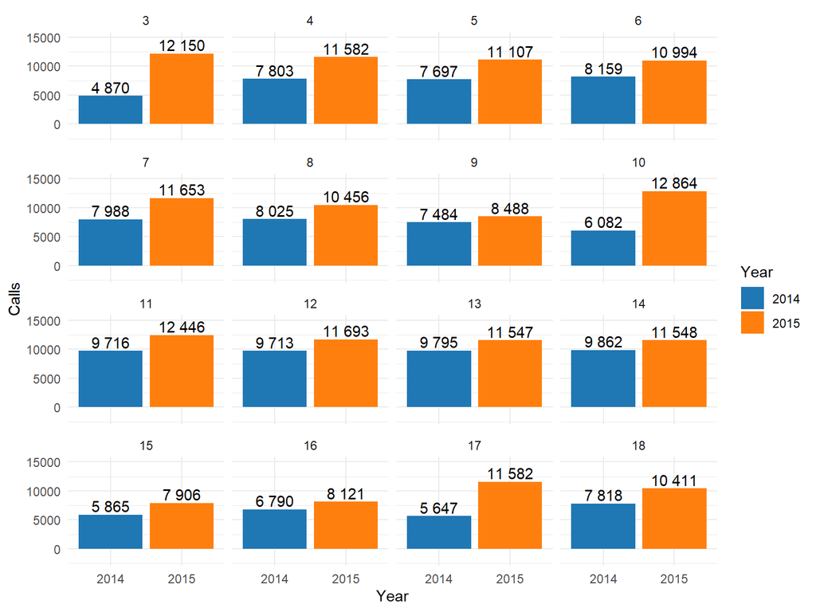

## Predictive Modeling

- Will be based on Machine Learning.
- Considered models
  - Linear Regression
  - Poisson Regression
  - Random Forest Regression
  - Support Vector Regression
  - kth Nearest Neighbour Regression
- Repeated 10-fold Cross Validation
- Assessed based on Minimum Root Mean Squared Error
- Linear Regression, the simplest model, turns out to be the best!
- Results can be found in appendix.
- Good thing about simple models - It is possible to see which variable has the greatest importance in prediction!

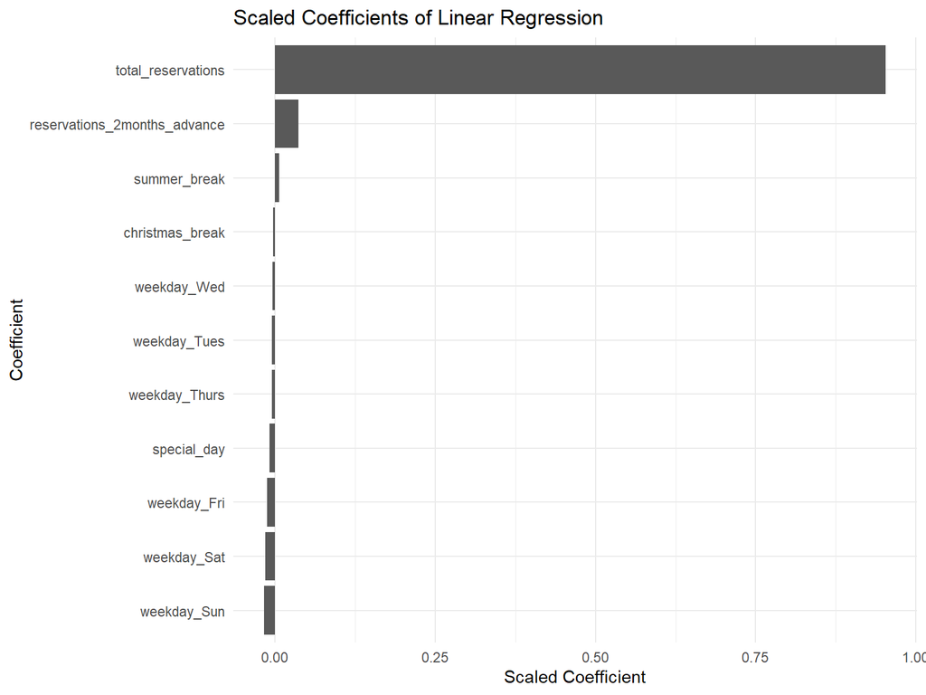

It can be observed that total_reservations is way a stronger predictor of calls than any other predictors.

## First Intuition on Headcount Planning

- The arrival rate, $\lambda$, can now be obtained from the predicted model.
- Let’s make the following assumptions:
  - It is possible to model number of customers serviced per day per employee (data not provided here)
  - Expected arrival Rate is uniform throughout the day (reasonable given MI.com is global)
  - Infinite Customer Population (reasonable)
  - Queue Length is unlimited
  - First Come First Serve

## M/M/1 Model

- M/M/1 model can be used. Let’s say the customer should not wait more than a certain period of time in the queue.

$$W_{s} = \frac{\lambda}{\mu(\mu - \lambda)}$$
where $W_{s}$ is time spent of a customer in the queue, $\lambda$ is call arrival rate, $\mu$ is call service rate. If servicing capabilities is additive (i.e. 2 employees double the service rate of a single employee),

$$W_{s}(n\mu)^{2}-W_{s}\lambda(n\mu)-\lambda = 0$$

It becomes a quadratic equation!!!! Then we will just solve for n!

- However, this is useful as a ballpark figure.
  - Service data should be collected.
  - Optimization and Simulation should be performed to derive the recommended headcount.

## Conclusion

- Calls peak in Aug, Trough in Feb
- Weekends less call than weekdays
- High correlation between Calls and Total Reservations
- Day of the week, reservations, advanced reservations, summer break, christmas break and special day have explanatory power on number of calls
- Outliers Detected for First Half of Aug 2015
- Total Reservations the single most powerful predictor on call rates
- Using M/M/1 model to guess number of head count
- More data required to model service rate

# Thank You Very Much!!!

## Appendix 1 - Goodness of Fit of Poisson Regression

```r
qchisq(0.95,11)
```

```
## [1] 19.67514
```

```r
model_poisson$null.deviance - model_poisson$deviance
```

```
## [1] 672265.6
```

Test of $\chi_{squared}$ suggested rejection of null hypothesis of no explanatory power, since it lies within the rejection zone

```r
qchisq(0.95,nrow(combined_data_model) - length(coef(model_poisson)))
```

```
## [1] 844.0001
```

```r
model_poisson$deviance
```

```
## [1] 54395.82
```

Goodness of Fit, however, is not established using $\chi_{squared}$. The null hypothesis of good fit is thus rejected since it lies within the rejection zone.

## Appendix 1 - Goodness of Fit of Poisson Regression

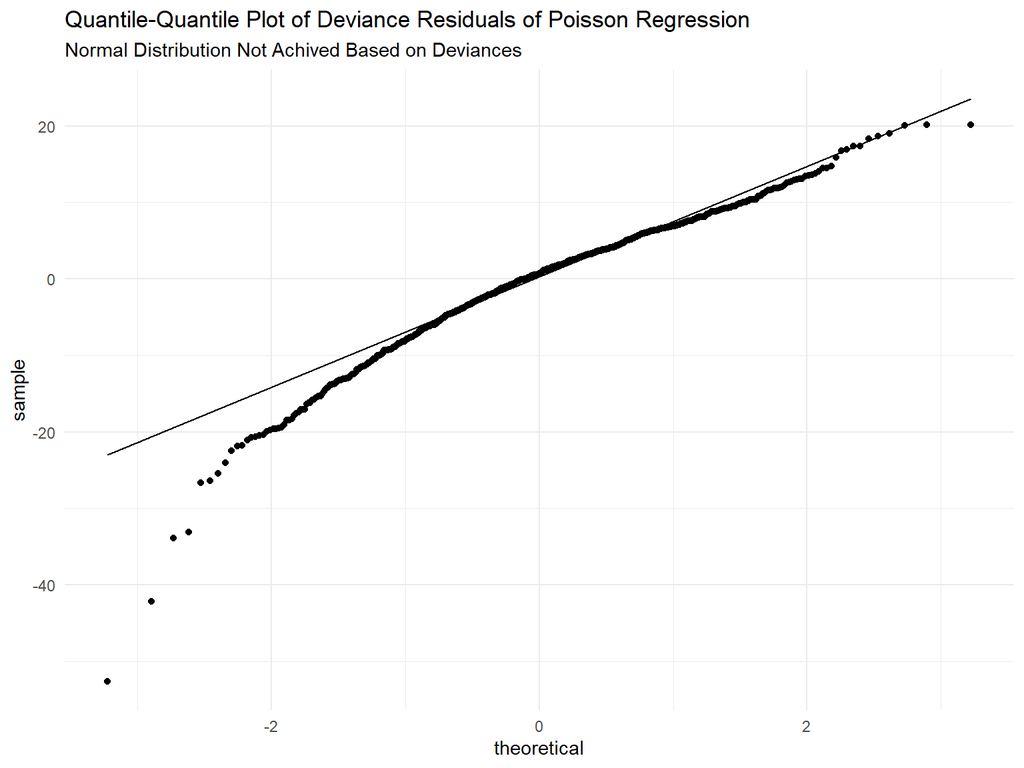

Normality does not seem to be lacking for the most part except the lower tail of the deviance.

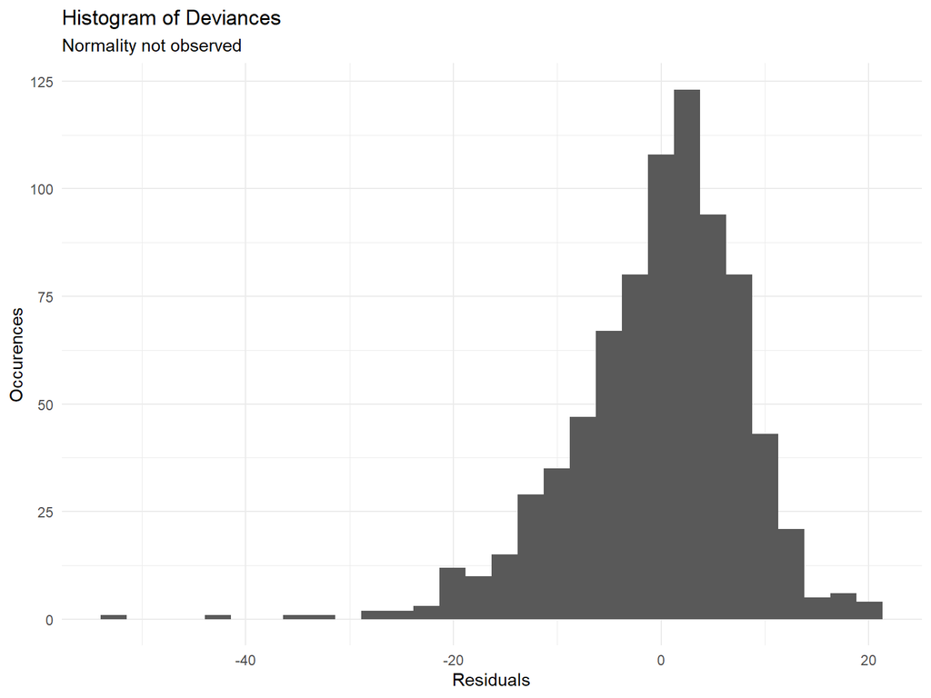

The histogram affirms what has been seen on quantile-quantile plot. Having data points so far to the left suggests presence of extreme outliers.

## Appendix 2 - Outliers

```r
car::vif(model_poisson)
```

```
##                                  GVIF Df GVIF^(1/(2*Df))
## weekday                      1.520044  6        1.035511
## reservations_2months_advance 5.341700  1        2.311212
## total_reservations           5.775281  1        2.403181
## summer_break                 2.245088  1        1.498362
## christmas_break              1.058963  1        1.029059
## special_day                  1.116389  1        1.056593
```

Multi-collinearity does not seem to be an issue.

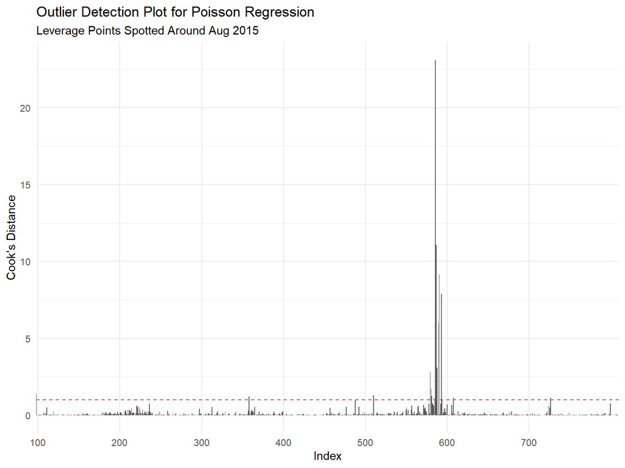

Extreme Cook’s Distance spotted between row index 580 and 600, corresponding to the Aug 2015 period.

## Appendix 3: Machine Learning Code

```r
# Setting the Seed

library(caret)

set.seed(13112020)

# Training + Validation Set

test_set <- combined_data_model %>%
  sample_frac(0.1)

# Test Set

train_set <- combined_data_model %>%
  anti_join(test_set)

# Set Control for Linear Regression & Poisson Regression

tc <- trainControl("repeatedcv",
                   number = 10,
                   repeats = 3,
                   savePredictions = TRUE)

# Poisson Regression

poisson_model_pred <- train(
  calls ~.,
  data = train_set,
  method = "glm",
  trControl = tc,
  family = poisson
)

# Linear Regression

linear_regression_model_pred <- train(
  calls ~.,
  data = train_set,
  method = "lm",
  trControl = tc
)

# Set Control for Regression with Variables (Set for Random Search)

control_rf <- trainControl(method = "repeatedcv",
                        number = 10,
                        repeats = 3,
                        search = "random",
                        savePredictions = TRUE)

# Random Forest

random_forest <- train(
  calls ~.,
  data = train_set,
  method = "rf",
  trControl = control_rf
)

# Support Vector Regression

## Scale dataset

train_set_dummies_scale <- fastDummies::dummy_cols(train_set,select_columns = c("weekday"),
                                                   remove_first_dummy = TRUE) %>%
  select(-weekday) %>%
  scale(.)

svr <- train(
  calls ~.,
  data = train_set_dummies_scale,
  method = "svmLinear",
  trControl = control_rf
)

# k-th Nearest Regression

knn <- train(
  calls ~.,
  data = train_set,
  method = "knn",
  trControl = control_rf
)

rmse_poisson <- tibble(method = "Poisson Regression",poisson_model_pred$results["RMSE"])
rmse_lm <- tibble(method = "Linear Regression",linear_regression_model_pred$results["RMSE"])
rf_results <- random_forest$results
rmse_rf <- tibble(method = "Ramdom Forest",RMSE = rf_results[which.min(rf_results$RMSE),"RMSE"])
svr_results <- svr$results
rmse_svr <- tibble(method = "Support Vector Regression",
                   RMSE = svr_results[which.min(svr_results$RMSE),"RMSE"] * sd(train_set$calls))
knn_results <- knn$results
rmse_knn <- tibble(method = "kth Nearest Neighbour Regression",
                   RMSE = knn_results[which.min(knn_results$RMSE),"RMSE"])
```

## Appendix 4: Machine Learning Model Selection

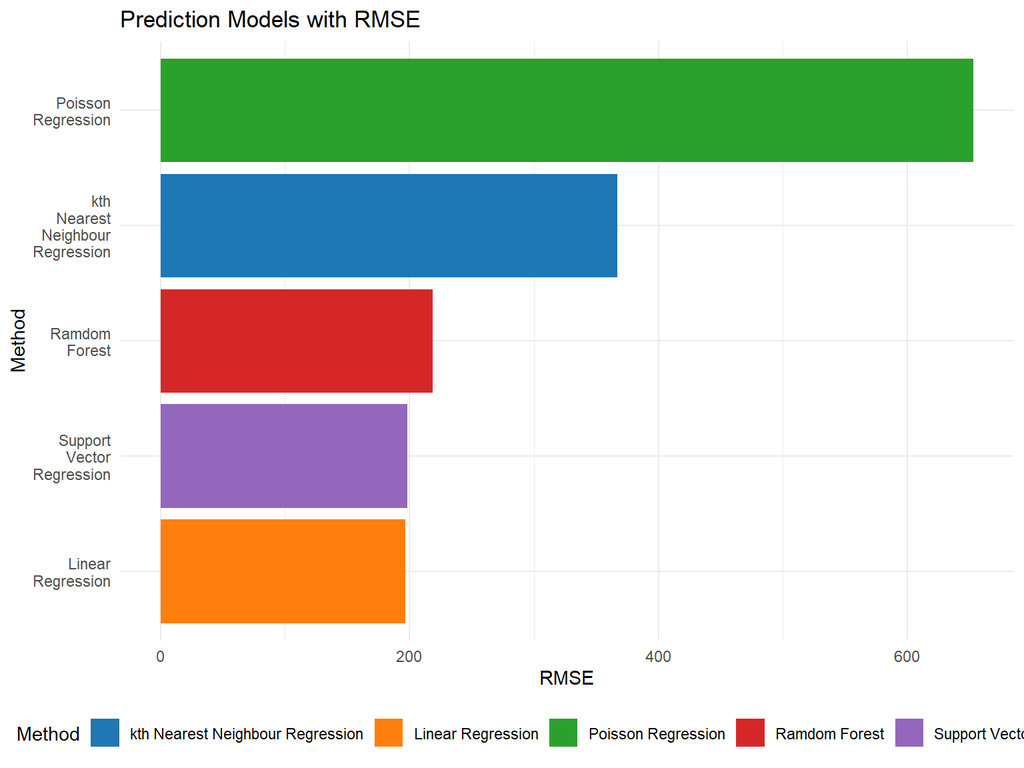

Comparison of Different Machine Learning Models Based on RMSE

```r
test_set %>%
  mutate(predicted_values = predict(linear_regression_model_pred,
                                    newdata = test_set)) %>%
  mutate(sqerror = (calls-predicted_values)^2) %>%
  summarise(RMSE = sqrt(sum(sqerror)/n()))
```

```
## # A tibble: 1 x 1
##    RMSE
##   <dbl>
## 1  179.
```

Final Check with Test Set. So far the test set result is very satisfactory.

## Appendix 5: Code Snippets

```r
setwd("C:/Users/tanya/OneDrive/Desktop")

library(tidyverse)
library(lubridate)
library(caret)

### Loading and Preparing the Data

data_calls <- read_delim("case_data_calls.csv",delim=";") %>%
  mutate_at(vars(date),~as.Date(., format = "%d-%m-%Y"))

data_resv <- read_delim("case_data_reservations.csv",delim = ";") %>%
  mutate_at(vars(date),~as.Date(., format = "%d-%m-%Y"))

combined_data <- data_calls %>%
  inner_join(data_resv,by=c("date"))

### Plot of Calls against Date

data_calls %>%
  ggplot(aes(x=date,y=calls)) +
  geom_line() +
  scale_x_date(date_breaks = "1 month") +
  theme_minimal() +
  theme(axis.text.x = element_text(angle = 90),
        panel.grid.minor.x = element_blank()) +
  scale_y_continuous(labels = scales::number) +
  labs(
    x = "Date",
    y= "Calls",
    title = "Chart of Calls against Date",
    subtitle = "Yearly Cycles of Peak in Aug, Trough in Feb"
  )

### Parametric Method

param <- combined_data_model %>%
  ggplot(aes(x=weekday,y=calls,fill=weekday)) +
  geom_boxplot(notch = TRUE) +
  ggsci::scale_fill_d3() +
  theme_classic() +
  xlab ("Day") +
  ylab("Calls") +
  scale_y_continuous(labels = scales::number) +
  labs(
    fill = "Day"
  ) +
  labs(
    title = "Non-Parametric Method of Estimating Median of Calls",
    subtitle = "Number of Calls Lower on Sat and Sun"
  )

### Non-Parametric Method

non_param <- combined_data_model %>%
  ggplot(aes(x=weekday,y=calls,colour=weekday)) +
  stat_summary(fun.data = "mean_cl_boot",
               fun.args = list(
                 conf.int = 0.95
               )) +
  theme_classic() +
  xlab ("Day") +
  ylab("Calls") +
  labs(
    caption = "Range based on 95% Confidence Interval",
    colour = "Day",
    title = "Parametric Method of Estimating Mean of Number of Calls",
    subtitle = "Number of Calls Lower on Sat and Sun"
  ) +
  ggsci::scale_color_d3() +
  scale_y_continuous(breaks = seq(2000,8000,by=1000),labels = scales::number)

ggpubr::ggarrange(param,non_param, nrow = 2)

### Plot of Reservations against Date

data_resv %>%
  ggplot(aes(x=date,y=total_reservations)) +
  geom_line() +
  scale_x_date(date_breaks = "6 month") +
  theme_classic() +
  theme(axis.text.x = element_text(angle = 90)) +
  scale_y_continuous(labels = scales::number) +
  labs(
    x = "Date",
    y= "Total Reservations",
    title = "Chart of Total Reservations against Date",
    subtitle = "Seasonal Effect coupled with cyclical effect"
  )

### Merging 2 Plots

combined_data %>%
  mutate_at(vars(total_reservations),~./2.5) %>%
  ggplot() +
  geom_line(aes(x=date,y=calls), colour = "tomato3") +
  geom_line(aes(x=date,y=total_reservations), colour = "deepskyblue4") +
  scale_y_continuous(
    name = "Calls",
    sec.axis = sec_axis(trans=~./2.5, name = "Total Reservations",
                        labels = scales::number),
    labels = scales::number
  ) +
  theme_classic() +
  labs(
    x = "Date",
    title = "Plotting both Calls and Reservations against Date"
  ) +
  scale_x_date(date_breaks = "6 month")

## Correlation

combined_corr <- combined_data %>%
  mutate(PreviousCalls = lag(calls,n=1,order_by = date),
         PreviousTotalReservations = lag(total_reservations,n=1,
                                         order_by = date))

### Correlation Test

cor.test(combined_corr$PreviousCalls,combined_corr$PreviousTotalReservations)

### Correlation Plot

ggplot(data=NULL,aes(x=combined_corr$PreviousCalls,y=combined_corr$PreviousTotalReservations)) +
  geom_point() +
  theme_classic() +
  geom_smooth(formula = y~x, method="lm", linetype = 2, colour = "tomato3") +
  labs(
    x = expression(Delta*" Calls (First Order Difference)"),
    y = expression(Delta*" Total Reservations (First Order Difference)"),
    title = "Correlation between First Order Difference of Calls against Total Reservations",
    subtitle = "Close Correlation Observed"
  ) +
  scale_x_continuous(labels=scales::number) +
  scale_y_continuous(labels=scales::number) +
  ggpmisc::stat_poly_eq(formula = y~x,
                        aes(label = ..rr.label..),
                        parse = TRUE)

# Poisson Regression (Exploratory)

combined_data_model <- combined_data %>%
  mutate_at(vars(weekday),~factor(.,
                                  levels = c(1,2,3,4,5,6,7),
                                  labels = c("Mon","Tues","Wed",
                                             "Thurs","Fri","Sat",
                                             "Sun"))) %>%
  select(-date)

model_poisson <- glm(calls~., data = combined_data_model,
                     family = "poisson")

summary(model_poisson)

## Test for Total Regressopm

qchisq(0.95,11)

model_poisson$null.deviance - model_poisson$deviance

## GOF Test

qchisq(0.95,nrow(combined_data_model) - length(coef(model_poisson)))

model_poisson$deviance

## Outlier Detection

### Chart

tibble(cooks_distance = cooks.distance(model_poisson)) %>%
  rownames_to_column(var="rowIndex") %>%
  ggplot(aes(x=factor(rowIndex),y=cooks_distance)) +
  geom_col() +
  scale_x_discrete(breaks = seq(0,nrow(combined_data_model),100)) +
  labs(
    x = "Index",
    y = "Cook's Distance",
    title = "Outlier Detection Plot for Poisson Regression",
    subtitle = "Leverage Points Spotted Around Aug 2015"
  ) +
  geom_hline(aes(yintercept = 1), linetype = 2, colour = "tomato3") +
  theme_minimal()

### Tibble

tibble(cooks_distance = cooks.distance(model_poisson)) %>%
  bind_cols(combined_data) %>%
  rownames_to_column(var="rowIndex") %>%
  mutate_at(vars(rowIndex),~as.integer(.)) %>%
  filter(rowIndex>=580 & rowIndex<=595)

### Outlier Plot

combined_data %>%
  mutate(month = month(date),
         day = day(date),
         year = year(date)) %>%
  filter(month ==8 & day %in% seq(3,18,1)) %>%
  mutate_at(vars(year),~as.factor(.)) %>%
  ggplot(aes(x=year,y=calls,fill=year)) +
  geom_col() +
  facet_wrap(~day) +
  theme_minimal() +
  geom_text(aes(label = scales::number(calls,accuracy = 1)), vjust = -0.25) +
  ggsci::scale_fill_d3() +
  scale_y_continuous(expand = expansion(0,3000)) +
  labs(
    fill = "Year",
    y = "Calls",
    x = "Year"
  )

### Base R Approach

plot(model_poisson)

## Goodness of Fit

ggplot(data=NULL, aes(sample = residuals(model_poisson,type = "deviance"))) +
  stat_qq() +
  stat_qq_line() +
  theme_classic() +
  labs(
    title = "Quantile-Quantile Plot of Deviance Residuals of Poisson Regression",
    subtitle = "Normal Distribution Not Achived Based on Deviances"
  )

ggplot(data=NULL, aes(x = residuals(model_poisson,type = "deviance"))) +
  geom_histogram() +
  theme_classic() +
  labs(
    x = "Residuals",
    y = "Occurences",
    title = "Histogram of Deviances",
    subtitle = "Normality not observed"
  )

## Variance Inflation Factor

car::vif(model_poisson)

# Machine Learning

### See Previous Snippet

## Model Comparison

rmse_poisson %>%
  bind_rows(rmse_lm,rmse_rf,rmse_svr,rmse_knn) %>%
  ggplot(aes(x=reorder(method,RMSE),y=RMSE,fill = method)) +
  geom_col() +
  coord_flip() +
  ggsci::scale_fill_d3() +
  theme_minimal() +
  theme(
    legend.position = "bottom"
  ) +
  labs(
    x = "Method",
    fill = "Method",
    title = "Prediction Models with RMSE"
  ) +
  scale_x_discrete(labels = function(x) str_wrap(x, width = 10))


## Linear Regression is the best fit

model_pred <- test_set %>%
  mutate(predicted_values = predict(linear_regression_model_pred,
                                    newdata = test_set)) %>%
  mutate(sqerror = (calls-predicted_values)^2) %>%
  summarise(RMSE = sqrt(sum(sqerror)/n()))

## Fit to Whole Model

combined_data_model_scaled <- combined_data_model %>%
  fastDummies::dummy_cols(select_columns = "weekday",
                          remove_first_dummy = TRUE) %>%
  select(-weekday) %>%
  scale(.) %>%
  as.data.frame(.)

chosen_model <- lm(calls~., data = combined_data_model_scaled )

# Top Coefficients of Linear Modeling

enframe(coef(chosen_model)) %>%
  arrange(desc(value)) %>%
  filter(name != "(Intercept)") %>%
  ggplot(aes(x=reorder(name,value),y=value)) +
  geom_col() +
  scale_x_discrete(labels = function(x) str_wrap(x, width = 5)) +
  theme_minimal() +
  coord_flip() +
  labs(
    y = "Scaled Coefficient",
    x = "Coefficient",
    title = "Scaled Coefficients of Linear Regression"
  )

# Curious - Check Linear Model Goodness-of-Fit

ggplot(data=NULL,aes(sample = MASS::stdres(chosen_model))) +
  stat_qq() +
  stat_qq_line()
```